# Rプログラミング入門 回帰分析の基礎

Cho（ztempest0218@gmail.com）

Last Updated: 2026-06-15

**今回の内容**

- 回帰分析とは
- 最小二乗法（OLS）
  - 残差平方和を最小化する
  - 単回帰モデルの推定量を導出する
  - OLS推定と因果推論
- Rによる回帰分析
  - `lm()` による推定
  - 標準誤差、t値、p値

**今回使用するデータ**

- ssdse_clean_sample_2018_2023.rds

# 1 回帰分析とは

回帰分析とは、ある変数を、別の変数または複数の変数によってどのように説明できるかを、数式と数値で表す方法である。特に線形回帰分析では、変数間の関係を直線・平面、より一般には超平面として近似する。

この授業では、まず最も単純な形として、1つの説明変数と1つの被説明変数の関係（単回帰）を考える。

たとえば、ある変数 $x$ と別の変数 $y$ の間に、右上がりや右下がりの関係があるように見えることがある。このとき、散布図を見るだけでなく、その関係を直線の傾きとして表すことができれば、関係の向きや強さを数値として比較できる。

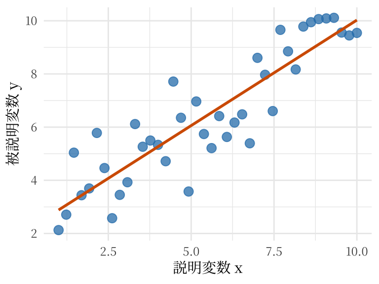

この直線をどのように選ぶのか。その代表的な方法が **最小二乗法** である。最小二乗法は、もともと社会科学の回帰分析だけのために作られた方法ではない。よく知られている例として、数学者ガウス（Carl Friedrich Gauss）は、観測データから小惑星ケレス（Ceres）の軌道を推定する際に、誤差を含む複数の観測値から最も整合的な軌道を求めたとされている。

天体観測では、観測には必ず誤差が含まれる。そのため、すべての観測点を完全に通る軌道を見つけることは難しい。そこで重要になるのは、観測値とのズレが全体として最も小さくなるような軌道を選ぶことである。この考え方が、最小二乗法の直感である。最小二乗法の原理は次の章で説明するので、ここではまず、実際のデータを使ってRで回帰分析を実行し、その結果を可視化する。

この直線を数式で書くと、次のような単回帰モデルになる。

$$y_i = \beta_0 + \beta_1 x_i + u_i$$

ここで、各記号の意味は以下の通りである。

| 記号 | 意味 |
| --- | --- |
| $y_i$ | 被説明変数。結果変数とも呼ぶ |
| $x_i$ | 説明変数。原因変数とも呼ぶ |
| $\beta_0$ | 切片 |
| $\beta_1$ | 傾き、または回帰係数 |
| $u_i$ | 誤差項 |
| $i$ | 観測値を表す添字 |

このうち、**$y_i$ と $x_i$ はデータに含まれている値**である。一方、$\beta_0$ と $\beta_1$ は直接観察できないため、データから推定する必要がある。Rで `lm()` を実行して得られるのは、サンプルデータから計算された $\hat{\beta}_0$ と $\hat{\beta}_1$ である。

例えば、都道府県 $i$ における出生数を $y_i$、婚姻件数を $x_i$ とすれば、次のように書ける。

$$\text{births}_i
= \beta_0 + \beta_1 \text{marriages}_i + u_i$$

この式では、$\beta_1$ が最も重要である。$\beta_1$ は、$\text{marriages}_i$ が1単位変化したとき、$\text{births}_i$ が平均的にどれくらい変化するかを表す。数式で書けば、次のようになる。

$$\beta_1
=
\frac{\partial \text{births}_i}{\partial \text{marriages}_i}$$

では、Rでこの回帰直線を推定してみる。線形回帰は `lm()` で実行する。基本形は `lm(y ~ x, data = データ名)` であり、`~` の左側に被説明変数、右側に説明変数を書く。

```r
rm(list = ls())

library(tidyverse)
library(showtext)

# 日本語フォント
font_add_google("Noto Serif JP", "notojp")
showtext_auto()

# 授業用データを読み込む
japan <- readRDS("./data/ssdse_clean_sample_2018_2023.rds")

# 2023年だけを取り出す
japan_2023 <- japan %>%
  filter(year == 2023)

# 単回帰モデルを推定する
model1 <- lm(
  births_per_1000 ~ marriages_per_1000,
  data = japan_2023
)

model1
```

```
##
## Call:
## lm(formula = births_per_1000 ~ marriages_per_1000, data = japan_2023)
##
## Coefficients:
##        (Intercept)  marriages_per_1000
##              2.104               1.048
```

この出力には、推定された切片と傾きが表示されている。`(Intercept)` は切片であり、`marriages_per_1000` はこの説明変数に対応する係数、つまり傾きである。別の説明変数を使えば、この部分にはその変数名が表示され、その変数に対応する係数を表す。つまり、Rは「千人あたり婚姻件数」と「千人あたり出生数」の関係を表す直線を1本選んだことになる。

推定結果を数式で書けば、次のように表せる。

$$\widehat{\text{births}}_i
= 2.104
+ 1.048 \times \text{marriages}_i$$

この推定では、傾きは 1.048 である。これは、千人あたり婚姻件数が1単位大きい都道府県では、千人あたり出生数が平均的に 1.048 単位大きいことを意味する。このように、説明変数が1単位変化したときに、被説明変数がどれくらい変化するかを **限界効果（marginal effect）** と呼ぶ。

この直線がデータの中でどのように見えるのかを、散布図と回帰直線で確認する。

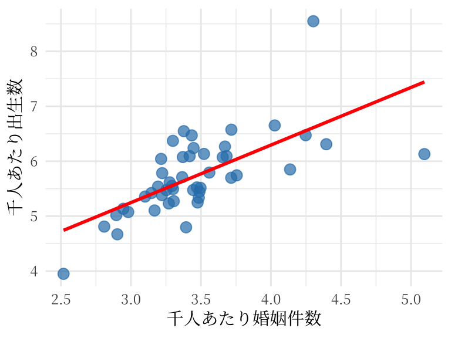

```r
ggplot(
  data = japan_2023,
  aes(
    x = marriages_per_1000,
    y = births_per_1000
  )
) +
  geom_point(
    size = 3,
    color = "#2C7FB8",
    alpha = 0.7
  ) +
  geom_smooth(method = "lm", se = FALSE, color = "red") +
  labs(
    x = "千人あたり婚姻件数",
    y = "千人あたり出生数"
  ) +
  theme_minimal(base_family = "notojp")
```

赤い直線が、線形回帰によって推定された回帰直線である。では、この直線はどのように決まっているのだろうか。

# 2 最小二乗法（OLS）

**OLS** は Ordinary Least Squares の略であり、日本語では「最小二乗法」または「最小自乗法」と呼ばれる。OLSの考え方は非常に単純である。実際の値と予測値の差を残差と呼び、その残差の二乗和が最も小さくなるように直線を一意に選ぶ。

データから推定された切片と傾きを使うと、**予測値**は次のように書ける。

$$\hat{y}_i = \hat{\beta}_0 + \hat{\beta}_1 x_i$$

実際の値 $y_i$ と予測値 $\hat{y}_i$ の差を残差と呼ぶ。

$$\hat{u}_i = y_i - \hat{y}_i
= y_i - \hat{\beta}_0 - \hat{\beta}_1 x_i$$

図で表すと、残差は各点から回帰直線までの縦方向のズレである。

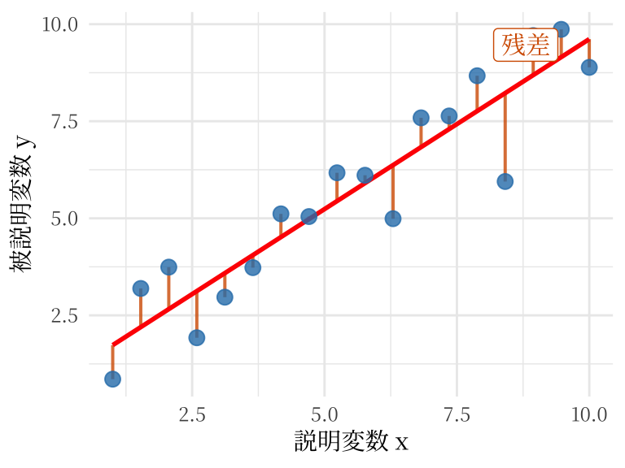

OLSでは、残差の二乗和を最小化する。

$$SSR
= \sum_{i=1}^{n} \hat{u}_i^2
= \sum_{i=1}^{n}
\left(y_i - \hat{\beta}_0 - \hat{\beta}_1 x_i\right)^2$$

ここで、SSRは Sum of Squared Residuals の略であり、残差平方和を意味する。これは、1つ1つの残差を二乗して足し合わせたものであり、モデル全体としてどれくらいズレが残っているかを表す。OLS推定量は、次の最小化問題として表せる。

$$\left(\hat{\beta}_0, \hat{\beta}_1\right)
=
\arg\min_{\hat{\beta}_0, \hat{\beta}_1}
\sum_{i=1}^{n}
\left(y_i - \hat{\beta}_0 - \hat{\beta}_1 x_i\right)^2$$

つまり、OLSは「どの切片と傾きを選べば、データ点と回帰直線の縦方向のズレが全体として最も小さくなるか」を考えている。

## 2.1 一階条件

残差平方和を最小化するために、$\hat{\beta}_0$ と $\hat{\beta}_1$ について偏微分し、それぞれ0とおく。整理すると、次の2つの一階条件が得られる。

$$\sum_{i=1}^{n}
\left(y_i - \hat{\beta}_0 - \hat{\beta}_1 x_i\right)
=0
\tag{1}$$

これは、残差の合計が0になることを意味する。

$$\sum_{i=1}^{n} \hat{u}_i = 0$$

$$\sum_{i=1}^{n}
x_i
\left(y_i - \hat{\beta}_0 - \hat{\beta}_1 x_i\right)
=0
\tag{2}$$

これは、説明変数 $x_i$ と残差の積の合計が0になることを意味する。

$$\sum_{i=1}^{n} x_i \hat{u}_i = 0$$

以上の2つの条件を使うと、OLS推定量を導出できる。

## 2.2 切片の推定量

一つ目の一階条件から出発する。

$$\sum_{i=1}^{n}
\left(y_i - \hat{\beta}_0 - \hat{\beta}_1 x_i\right)
=0$$

和を展開すると、

$$\sum_{i=1}^{n} y_i
- \sum_{i=1}^{n} \hat{\beta}_0
- \hat{\beta}_1 \sum_{i=1}^{n} x_i
=0$$

$\hat{\beta}_0$ は定数なので、$\sum_{i=1}^{n} \hat{\beta}_0 = n\hat{\beta}_0$ である。したがって、

$$\sum_{i=1}^{n} y_i
- n\hat{\beta}_0
- \hat{\beta}_1 \sum_{i=1}^{n} x_i
=0$$

両辺を $n$ で割ると、

$$\bar{y}
- \hat{\beta}_0
- \hat{\beta}_1 \bar{x}
=0$$

したがって、切片の推定量は次のように表せる。

$$\hat{\beta}_0
= \bar{y} - \hat{\beta}_1 \bar{x}$$

この式は、OLSの回帰直線が必ずサンプル平均の点 $(\bar{x}, \bar{y})$ を通ることを意味している。

## 2.3 傾きの推定量

次に、傾き $\hat{\beta}_1$ の推定量を導出する。

二つ目の一階条件は次の通りである。

$$\sum_{i=1}^{n}
x_i
\left(y_i - \hat{\beta}_0 - \hat{\beta}_1 x_i\right)
=0$$

先ほど導出した

$$\hat{\beta}_0
= \bar{y} - \hat{\beta}_1 \bar{x}$$

を代入する。

$$\sum_{i=1}^{n}
x_i
\left[
y_i - \left(\bar{y} - \hat{\beta}_1 \bar{x}\right)
- \hat{\beta}_1 x_i
\right]
=0$$

括弧の中を整理すると、

$$\sum_{i=1}^{n}
x_i
\left[
(y_i - \bar{y})
- \hat{\beta}_1 (x_i - \bar{x})
\right]
=0$$

ここで、$x_i$ は $(x_i - \bar{x}) + \bar{x}$ と書ける。残差の合計が0であることを使うと、最終的に次の形に整理できる。

$$\sum_{i=1}^{n}
(x_i - \bar{x})(y_i - \bar{y})
-
\hat{\beta}_1
\sum_{i=1}^{n}
(x_i - \bar{x})^2
=0$$

したがって、傾きの推定量は次の通りである。

$$\hat{\beta}_1
=
\frac{
\sum_{i=1}^{n}
(x_i-\bar{x})(y_i-\bar{y})
}{
\sum_{i=1}^{n}
(x_i-\bar{x})^2
}$$

この式の分子は、$x$ と $y$ が一緒に動く程度を表している。分母は、$x$ 自身がどれくらいばらついているかを表している。分子と分母を同じ定数 $n$ で割れば、これは共分散を分散で割った形として理解できる。

$$\hat{\beta}_1
=
\frac{\operatorname{Cov}(x,y)}{\operatorname{Var}(x)}$$

したがって、$\hat{\beta}_1$ は「$x$ の変化に対して、$y$ が平均的にどれくらい変化するか」を表す。

まとめると、単回帰のOLS推定量は次のように書ける。

$$\left\{
\begin{aligned}
\hat{\beta}_1
&=
\frac{
\sum_{i=1}^{n}
(x_i-\bar{x})(y_i-\bar{y})
}{
\sum_{i=1}^{n}
(x_i-\bar{x})^2
}
\\
\hat{\beta}_0
&=
\bar{y} - \hat{\beta}_1 \bar{x}
\end{aligned}
\right.$$

## 2.4 RでOLS推定量を計算する

ここでは、先ほど導出した公式をRで直接計算してみる。被説明変数を `births_per_1000`、説明変数を `marriages_per_1000` とする。

```r
x <- japan_2023$marriages_per_1000
y <- japan_2023$births_per_1000

beta1_hat <- sum((x - mean(x)) * (y - mean(y))) /
  sum((x - mean(x))^2)

beta1_hat
```

```
## [1] 1.047721
```

```r
beta0_hat <- mean(y) - beta1_hat * mean(x)

beta0_hat
```

```
## [1] 2.104221
```

これが、手計算によって求めたOLS推定量である。次に、先ほど `lm()` で推定した結果と比較してみる。

```r
coef(model1)
```

```
##        (Intercept) marriages_per_1000
##           2.104221           1.047721
```

手計算で求めた値と、`lm()` の結果が一致していることがわかる。つまり、`lm()` はブラックボックスではなく、内部ではOLS推定量を計算している。

## 2.5 OLS推定と因果推論

ここまでで、OLS推定量そのものは導出できた。OLSは、データに含まれる $x$ と $y$ の関係を、一本の直線として要約する方法である。したがって、初歩的なデータ分析として、`lm()` で回帰直線を引き、係数を確認することには大きな意味がある。

ただし、ここで得られた係数をそのまま **因果効果（真の効果）として読むことはできない**。OLSはデータさえあれば機械的に計算できるが、その係数が因果関係を表すかどうかは、データの作られ方やモデルの仮定に依存する。

例えば、教育年数と賃金の関係を考える。教育年数が長い人ほど賃金が高いという関係が推定されたとしても、それだけで「教育年数を1年増やせば、誰でも同じだけ賃金が上がる」とは言えない。

係数を因果効果として読むためには、説明変数 $x_i$ と誤差項 $u_i$ が関係していない必要がある。単純に書けば、次の条件である。

$$\operatorname{Cov}(x_i, u_i) = 0$$

しかし、教育年数 $x_i$ と賃金 $y_i$ の両方に影響する別の要因があるかもしれない。代表的なのが **ability bias** である。能力が高い人や努力する人ほど、より長い教育年数を選びやすく、同時に賃金も高くなりやすい。能力や努力がモデルに入っていなければ、それらは誤差項 $u_i$ に含まれるため、$\operatorname{Cov}(x_i,u_i)=0$ は成り立たない。

また、教育は能力や努力を企業に伝えるシグナルとして働く可能性もある。したがって、この段階のOLSはあくまで初歩的な関係の確認であり、99%の場合、これだけでは因果推論はできない。因果関係を主張するには、$\operatorname{Cov}(x_i,u_i)=0$ と考えてよい理由を別途検討する必要がある。

# 3 Rで回帰分析を実行する

## 3.1 重回帰分析

Rで線形回帰を行う基本的な関数は `lm()` である。`lm()` は linear model の略である。

単回帰では説明変数を1つだけ用いた。しかし、実際の社会現象は1つの要因だけで決まるわけではない。出生数も、婚姻件数だけでなく、人口移動、所得水準、住宅価格、保育環境など、さまざまな要因と関係している可能性がある。

複数の説明変数を同時に用いる回帰分析を **重回帰分析** という。

$$y_i
=
\beta_0
+
\beta_1 x_{1i}
+
\beta_2 x_{2i}
+
\beta_3 x_{3i}
+
u_i$$

説明変数が1つの単回帰では、回帰モデルは散布図の中の直線として描ける。説明変数が2つになると、回帰モデルは三次元空間の中の平面として理解できる。

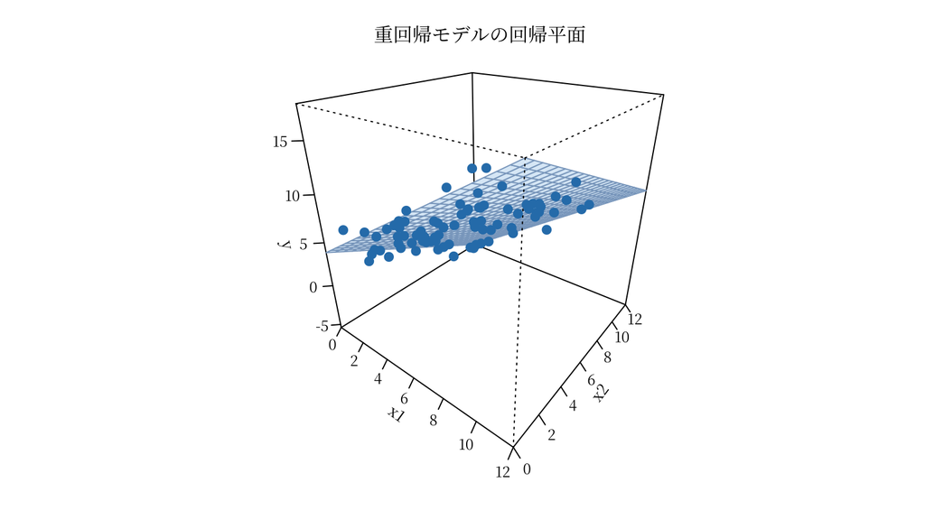

青い点が観測値であり、薄い青色の面が重回帰によって推定された平面である。説明変数がさらに増えると図で描くことは難しくなるが、考え方は同じである。

例えば、次のようなモデルを考える。

$$\text{births}_i
=
\beta_0
+
\beta_1 \text{marriages}_i
+
\beta_2 \text{migration}_i
+
\beta_3 \text{consumption}_i
+
u_i$$

Rでは、`+` を使って説明変数を追加する。

```r
lm(被説明変数 ~ 説明変数1 + 説明変数2 + ..., data = データ名)
```

ここで、`~` の左側に被説明変数、右側に説明変数を書く。

```r
model2 <- lm(
  births_per_1000 ~
    marriages_per_1000 +
    net_migration_per_1000 +
    household_consumption,
  data = japan_2023
)

summary(model2)
```

```
##
## Call:
## lm(formula = births_per_1000 ~ marriages_per_1000 + net_migration_per_1000 +
##     household_consumption, data = japan_2023)
##
## Residuals:
##      Min       1Q   Median       3Q      Max
## -1.07641 -0.26488  0.00946  0.24832  1.39320
##
## Coefficients:
##                          Estimate Std. Error t value Pr(>|t|)
## (Intercept)             2.850e+00  1.493e+00   1.909   0.0629 .
## marriages_per_1000      1.427e+00  2.559e-01   5.576 1.51e-06 ***
## net_migration_per_1000 -8.895e-02  6.052e-02  -1.470   0.1489
## household_consumption  -7.456e-06  3.213e-06  -2.321   0.0251 *
## ---
## Signif. codes:  0 '***' 0.001 '**' 0.01 '*' 0.05 '.' 0.1 ' ' 1
##
## Residual standard error: 0.4811 on 43 degrees of freedom
## Multiple R-squared:  0.5639, Adjusted R-squared:  0.5335
## F-statistic: 18.53 on 3 and 43 DF,  p-value: 7.251e-08
```

`summary(model2)` では、回帰分析の結果が詳しく表示される。最初はすべてを理解する必要はないが、まず次の部分を確認すればよい。

| 項目 | 意味 |
| --- | --- |
| `Estimate` | 推定された係数 |
| `Std. Error` | 係数の標準誤差 |
| `t value` | t値 |
| `Pr(>\|t\|)` | p値 |
| `Residual standard error` | 残差の標準誤差。誤差項の標準誤差の推定値 |
| `(Multiple) R-squared` | 決定係数 |

重回帰分析の係数は、「他の説明変数を一定にしたとき」の関係として読む。例えば、$\beta_1$ は、$x_2$ と $x_3$ を一定にしたときの、$x_1$ と $y$ の関係を表す。

ただし、説明変数を追加しても、因果関係が自動的にわかるわけではない。

## 3.2 標準誤差、t値、p値

`summary()` の出力では、係数だけでなく、その係数がどれくらい不確実かも表示される。ここで重要になるのが、残差の標準誤差、係数の標準誤差、t値、p値である。

まず、回帰直線からのズレである残差を使って、残差の標準誤差を計算する。$n$ を観測数、$k$ を説明変数の数とすると、

$$\hat{\sigma}
=
\sqrt{
\frac{\sum_{i=1}^{n}\hat{u}_i^2}
{n-k-1}
}$$

となる。これは、モデルで説明しきれなかったズレの大きさを表す。 $n-k-1$ は残差の自由度である。回帰分析では、切片と $k$ 個の係数をデータから推定するため、その分だけ自由に動ける情報が減る。

係数の標準誤差は、この残差の大きさをもとに計算される。残差が大きいほど係数の推定は不確実になり、説明変数に十分なばらつきがあるほど係数は推定しやすくなる。

単回帰の場合、傾きの標準誤差は次のように書ける。

$$\operatorname{SE}(\hat{\beta}_1)
=
\frac{\hat{\sigma}}
{\sqrt{\sum_{i=1}^{n}(x_i-\bar{x})^2}}$$

重回帰では、他の説明変数との関係も標準誤差に影響する。説明変数同士が強く相関していると、係数の標準誤差は大きくなりやすい。

ここまでで、$\hat{\beta}_j$ という係数の数値は得られる。しかし、その値が本当に意味のある関係を示しているのか、それともサンプルの偶然によってたまたま出た値なのかは、係数の大きさだけでは判断できない。そこで、標準誤差を使って仮説検定を行う。

係数が0と異なるかどうかを調べるときは、まず「係数は0である」と仮定する。

$$H_0: \beta_j = 0$$

これは、背理法に近い考え方である。いったん「係数は0である」と仮定し、その仮定のもとで今回のような推定値がどれほど珍しいかを確認する。

t値は、推定値が標準誤差の何個分だけ0から離れているかを表す。

$$t
=
\frac{\hat{\beta}_j - \beta_{j,0}}
{\operatorname{SE}(\hat{\beta}_j)}$$

帰無仮説では $\beta_{j,0}=0$ なので、次の形になる。

$$t
=
\frac{\hat{\beta}_j}
{\operatorname{SE}(\hat{\beta}_j)}$$

帰無仮説が正しければ、このt値は自由度 $n-k-1$ のt分布に従う。

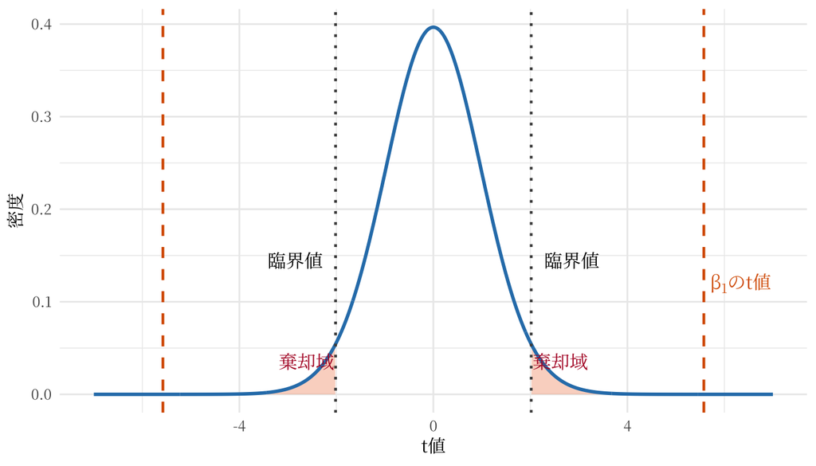

上の図では、青い曲線が帰無仮説のもとでのt分布である。灰色の点線は5%水準の両側検定における臨界値、薄い赤色の部分は棄却域、オレンジ色の破線は $\hat{\beta}_1$ のt値を表す。

よく使われる $1.96$ は、標本サイズが十分大きいときの標準正規分布による近似である。t分布を使う場合、臨界値は自由度によって変わる。

$\hat{\beta}_1$ のt値が棄却域に入れば、帰無仮説を棄却する。

p値は、$\hat{\beta}_1$ のt値と同じくらい、またはそれ以上に極端な値が出る確率である。p値が小さいほど、$\beta_1 = 0$ という仮説のもとでは起こりにくい結果だと判断する。

例えば、有意水準を5%とする場合、次のように判断する。

- $p < 0.05$：帰無仮説を棄却する
- $p \geq 0.05$：帰無仮説を棄却できない

実際の分析では、係数の絶対値がおおよそ標準誤差の2倍を超えると、t値はおおよそ $1.96$ を超え、p値は5%より小さくなりやすい。この場合、$\beta_1 = 0$ という帰無仮説を棄却し、係数は0ではないと判断する。

ただし、係数が0ではないことは、因果効果であることを意味しない。p値は「0と区別できるか」を見るための指標であり、因果関係の判断には別の仮定が必要である。

## 3.3 複数のモデルを比較する

回帰分析では、1つのモデルだけを示すのではなく、複数のモデルを比較して頑健性（Robustness）をチェックすることが多い。ここでは、次のモデルを比較する。

- 単回帰
- 重回帰
- 人口ウェイトを使った重回帰

ここまでの回帰分析では、47都道府県をすべて同じ重みで扱っている。つまり、東京都も鳥取県も、回帰分析の中では同じ1つの観測値である。一方で、人口全体に近い解釈をしたい場合には、人口の多い都道府県をより大きく反映させる必要がある。

Rの `lm()` では、`weights` を指定することで加重最小二乗法（weighted least squares）を行うことができる。ここでは、重回帰モデルに人口ウェイトを加える。

```r
model2_weighted <- lm(
  births_per_1000 ~
    marriages_per_1000 +
    net_migration_per_1000 +
    household_consumption,
  data = japan_2023,
  weights = population
)

summary(model2_weighted)
```

```
##
## Call:
## lm(formula = births_per_1000 ~ marriages_per_1000 + net_migration_per_1000 +
##     household_consumption, data = japan_2023, weights = population)
##
## Weighted Residuals:
##      Min       1Q   Median       3Q      Max
## -1811.37  -326.35    47.35   262.49  2249.92
##
## Coefficients:
##                          Estimate Std. Error t value Pr(>|t|)
## (Intercept)             5.164e+00  1.299e+00   3.975 0.000265 ***
## marriages_per_1000      8.224e-01  1.961e-01   4.195 0.000134 ***
## net_migration_per_1000 -3.863e-02  5.201e-02  -0.743 0.461683
## household_consumption  -8.072e-06  3.194e-06  -2.528 0.015244 *
## ---
## Signif. codes:  0 '***' 0.001 '**' 0.01 '*' 0.05 '.' 0.1 ' ' 1
##
## Residual standard error: 741.5 on 43 degrees of freedom
## Multiple R-squared:  0.4667, Adjusted R-squared:  0.4295
## F-statistic: 12.54 on 3 and 43 DF,  p-value: 5.027e-06
```

重回帰と、人口ウェイトを使った重回帰の違いは、あとで回帰表にまとめて比較する。

図では、単回帰の回帰直線を使って人口ウェイトの影響を確認する。青い線は都道府県を同じ重みで扱った回帰直線、赤い線は人口ウェイトを使った回帰直線である。

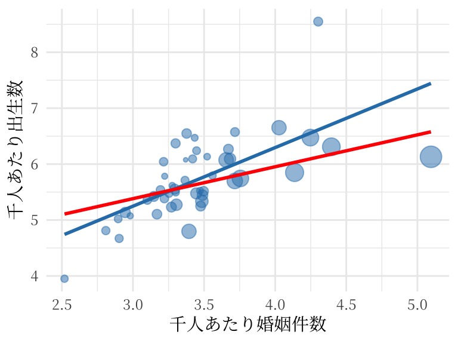

```r
ggplot(
  data = japan_2023,
  aes(
    x = marriages_per_1000,
    y = births_per_1000
  )
) +
  geom_point(
    aes(size = population),
    color = "#2C7FB8",
    alpha = 0.5
  ) +
  geom_smooth(
    method = "lm",
    se = FALSE,
    color = "#2C7FB8",
    linewidth = 1
  ) +
  geom_smooth(
    aes(weight = population),
    method = "lm",
    se = FALSE,
    color = "red",
    linewidth = 1
  ) +
  scale_size_continuous(guide = "none") +
  labs(
    x = "千人あたり婚姻件数",
    y = "千人あたり出生数"
  ) +
  theme_minimal(base_family = "notojp")
```

未加重と人口ウェイトのどちらを使うべきかは、研究上の問いによって決まる。都道府県を同じ1単位として比較したい場合は未加重の回帰を使う。一方、人口の多い地域をより強く反映したい場合は人口ウェイトを使う。実際の分析では、どちらを主な結果とするかを説明したうえで、もう一方を頑健性の確認として示すことが多い。

最後に、`modelsummary` パッケージを使って、論文やレポートで使いやすい回帰表を作成する。

```r
# install.packages("modelsummary")
library(modelsummary)

modelsummary(
  list(
    "Model 1" = model1,
    "Model 2" = model2,
    "Model 3" = model2_weighted
  ),
  stars = TRUE,
  gof_map = c("nobs", "r.squared", "adj.r.squared")
)
```

|  | Model 1 | Model 2 | Model 3 |
| --- | --- | --- | --- |
| (Intercept) | 2.104** | 2.850+ | 5.164*** |
|  | (0.607) | (1.493) | (1.299) |
| marriages_per_1000 | 1.048*** | 1.427*** | 0.822*** |
|  | (0.174) | (0.256) | (0.196) |
| net_migration_per_1000 |  | -0.089 | -0.039 |
|  |  | (0.061) | (0.052) |
| household_consumption |  | -0.000* | -0.000* |
|  |  | (0.000) | (0.000) |
| Num.Obs. | 47 | 47 | 47 |
| R2 | 0.445 | 0.564 | 0.467 |
| R2 Adj. | 0.433 | 0.533 | 0.429 |

+ p < 0.1, * p < 0.05, ** p < 0.01, *** p < 0.001

`modelsummary()` を使うと、複数のモデルを横に並べて比較できる。説明変数を追加したとき、また人口ウェイトを使ったときに、係数の大きさや統計的有意性がどのように変化するかを確認しやすい。

## 3.4 回帰分析の前処理

回帰分析では、`lm()` を実行する前のデータ処理も重要である。同じデータを使っていても、変数の作り方や単位の取り方によって、係数の読み方は大きく変わる。

**第一に、変数の単位に注意する必要がある。**例えば、消費支出を円単位で入れると、「1円増えたとき」の係数になるため、数値が非常に小さく見える。この場合、千円単位や万円単位に変換すると、係数を読みやすくなる。

```r
japan_2023 <- japan_2023 %>%
  mutate(
    household_consumption_1000 = household_consumption / 1000
  )
```

**第二に、対数変換を使うことも多い。**例えば、所得や人口のように分布の偏りが大きい変数は、対数を取ることで外れ値の影響を小さくし、関係を読みやすくできる。ただし、すべての変数を機械的に対数にすればよいわけではない。どの変数に対数を取るかによって、係数の解釈は変わる。

次の図は、右側に大きく偏った変数を対数変換した例である。元の値では一部の大きな値が目立つが、対数を取ると極端な値の影響が圧縮され、分布の形を確認しやすくなる。

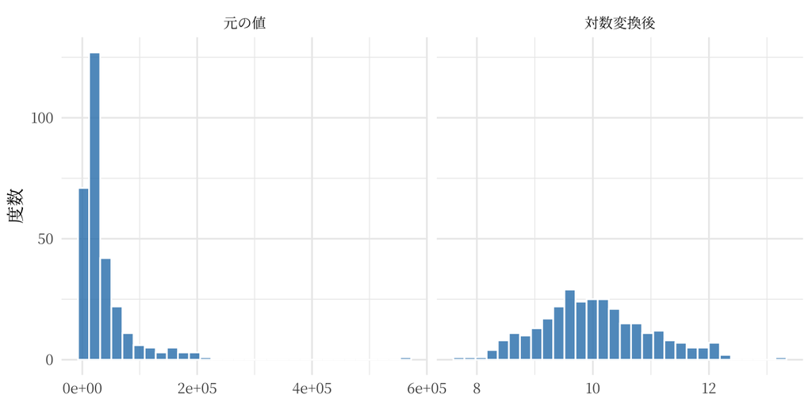

```r
data <- data %>%
  mutate(
    log_income = log(income),
    log_consumption = log(consumption)
  )
```

$$\log(y_i)
=
\beta_0
+
\beta_1 \log(x_i)
+
u_i$$

よく使われる形は、次の4つである。

| モデル | 係数の読み方 |
| --- | --- |
| $y_i = \beta_0 + \beta_1 x_i + u_i$ | $x$ が1単位増えたとき、$y$ が平均的に何単位変化するか |
| $\log(y_i) = \beta_0 + \beta_1 x_i + u_i$ | $x$ が1単位増えたとき、$y$ が平均的に約 $100\beta_1$% 変化するか |
| $y_i = \beta_0 + \beta_1 \log(x_i) + u_i$ | $x$ が1%増えたとき、$y$ が平均的に約 $\beta_1/100$ 単位変化するか |
| $\log(y_i) = \beta_0 + \beta_1 \log(x_i) + u_i$ | $x$ が1%増えたとき、$y$ が平均的に約 $\beta_1$% 変化するか |

ここで「約」と書いているのは、対数の変化をパーセント変化として近似しているためである。

最後の形は log-log モデルと呼ばれ、$\beta_1$ は弾力性として解釈できる。これは、次のように微分するとわかりやすい。

$$\frac{\partial \log(y_i)}
{\partial \log(x_i)}
=
\beta_1$$

ここで、$\partial \log(y_i)$ は $y_i$ のパーセント変化、$\partial \log(x_i)$ は $x_i$ のパーセント変化として近似できる。したがって、次のように理解できる。

$$\frac{\partial \log(y_i)}
{\partial \log(x_i)}
\simeq
\frac{\partial y_i/y_i}
{\partial x_i/x_i}$$

右辺は、「$x$ が1%変化したとき、$y$ が平均的に何%変化するか」を表しており、これはミクロ経済学で学ぶ弾力性そのものである。例えば、需要量を $y$、価格を $x$ として需要の価格弾力性を推定したい場合には、$\log(y)$ を $\log(x)$ で説明する log-log モデルを使うことが多い。

一方で、失業率、就業率のように、もともと「率」として定義されている変数は、そのまま使う方が解釈しやすいことも多い。対数を取るかどうかは、変数の分布、単位、そして係数をどのように解釈したいかによって決める。注意すべき点として、合計特殊出生率は、平均的に女性が一生に生む子どもの数を表す指標であり、犯罪率や結婚率も10万人あたりの犯罪件数・結婚件数として定義されることがある。このような変数は、ここでいう「率」とは限らない。必ず変数の定義を確認すること。

**第三に、欠損値や外れ値を確認する必要がある。**欠損値が多い変数を使うと、回帰に使われる観測数が大きく減ることがある。また、極端な外れ値がある場合、少数の観測値だけで係数が大きく変わる可能性がある。

**第四に、多重共線性にも注意する必要がある。**多重共線性とは、複数の説明変数が互いに強く相関している状態を指す。例えば、$x_1$、$x_2$、$x_3$ がほとんど同じように動いている場合、回帰分析を行っても、それぞれの変数の効果をうまく分けて推定することは難しい。

例えば、サッカー選手の賃金を分析する場合、ドリブル能力が高いトップ選手は、加速力も高く、シュート精度も高いことが多い。このとき、ドリブル能力、加速力、シュート精度を同時に説明変数に入れても、それぞれが賃金に与える効果をきれいに分離することは難しい。

簡単なシミュレーションで確認してみる。ここでは、$x_1$、$x_2$、$x_3$ がほとんど同じ潜在能力を反映しているようなデータを作る。

```r
set.seed(123)

n <- 100
ability <- rnorm(n)

multicollinearity_data <- tibble(
  x1 = ability + rnorm(n, mean = 0, sd = 0.1),
  x2 = ability + rnorm(n, mean = 0, sd = 0.1),
  x3 = ability + rnorm(n, mean = 0, sd = 0.1),
  y = 1 + 2 * x1 + rnorm(n, mean = 0, sd = 1)
)

round(
  cor(
    multicollinearity_data %>%
      select(x1, x2, x3)
  ),
  3
)
```

```
##       x1    x2    x3
## x1 1.000 0.989 0.988
## x2 0.989 1.000 0.988
## x3 0.988 0.988 1.000
```

このデータでは、$x_1$、$x_2$、$x_3$ の相関が非常に高い。まず、$x_1$ だけを使って回帰する。

```r
model_single_x <- lm(
  y ~ x1,
  data = multicollinearity_data
)

summary(model_single_x)
```

```
##
## Call:
## lm(formula = y ~ x1, data = multicollinearity_data)
##
## Residuals:
##     Min      1Q  Median      3Q     Max
## -2.4516 -0.6011  0.1251  0.6572  2.4665
##
## Coefficients:
##             Estimate Std. Error t value Pr(>|t|)
## (Intercept)  1.12367    0.09767   11.51   <2e-16 ***
## x1           1.77630    0.10709   16.59   <2e-16 ***
## ---
## Signif. codes:  0 '***' 0.001 '**' 0.01 '*' 0.05 '.' 0.1 ' ' 1
##
## Residual standard error: 0.973 on 98 degrees of freedom
## Multiple R-squared:  0.7374, Adjusted R-squared:  0.7347
## F-statistic: 275.1 on 1 and 98 DF,  p-value: < 2.2e-16
```

次に、$x_1$、$x_2$、$x_3$ を同時に入れて回帰する。

```r
model_multi_x <- lm(
  y ~ x1 + x2 + x3,
  data = multicollinearity_data
)

summary(model_multi_x)
```

```
##
## Call:
## lm(formula = y ~ x1 + x2 + x3, data = multicollinearity_data)
##
## Residuals:
##      Min       1Q   Median       3Q      Max
## -2.48127 -0.57695  0.05575  0.65750  2.49843
##
## Coefficients:
##             Estimate Std. Error t value Pr(>|t|)
## (Intercept)   1.1156     0.1001  11.142   <2e-16 ***
## x1            1.2131     0.8535   1.421    0.158
## x2            0.2134     0.8285   0.258    0.797
## x3            0.3576     0.7918   0.452    0.653
## ---
## Signif. codes:  0 '***' 0.001 '**' 0.01 '*' 0.05 '.' 0.1 ' ' 1
##
## Residual standard error: 0.9807 on 96 degrees of freedom
## Multiple R-squared:  0.7386, Adjusted R-squared:  0.7305
## F-statistic: 90.43 on 3 and 96 DF,  p-value: < 2.2e-16
```

真のデータ生成では、$y$ は主に $x_1$ によって決まるように作っている。しかし、$x_1$、$x_2$、$x_3$ が強く相関しているため、重回帰ではそれぞれの係数が不安定になり、標準誤差も大きくなりやすい。このように、説明変数同士が似た情報を持っている場合、回帰分析だけで「どの変数が本当に効いているのか」を分けることは難しい。

同じことは、教育年数と年齢の関係にも当てはまる。人は教育年数が1年増えると、通常は年齢も1歳上がる。そのため、教育年数と年齢は強く相関しやすい。賃金関数では、年齢や経験年数に加えて、その二乗項を入れることが多いが、これは年齢と賃金の関係が単純な直線ではない可能性を考慮するためでもある。どの変数を同時に入れるべきかは、単にデータだけでなく、理論や現実の制度を踏まえて考える必要がある。

つまり、回帰分析は `lm()` を実行するだけでは終わらない。どの変数を使うか、単位をどうそろえるか、対数を取るべきか、欠損値や外れ値、多重共線性をどう扱うかを考えることも、実証分析の重要な一部である。

# 4 課題

今回、具体的な課題は設定しない。ただし、データ可視化プロジェクトの中で、関心のある2つ以上の変数について回帰分析を試してみてもよい。

その場合、係数の解釈には十分注意すること。`lm()` を実行すれば必ず回帰結果は出るが、その結果が正しいとは限らない。特に、係数が統計的に有意であっても、それだけで因果関係を意味するわけではない。

回帰分析を本格的に使いたい学生は、統計的手法を用いるゼミや実証分析を扱う授業に参加してほしい。多くの回帰分析の結果は、そのままでは誤って解釈される可能性がある。どの結果が信頼でき、どの結果が危ういのかを判断するには、多くの経験とデータに対する直感が必要である。ただし、回帰分析は因果推論や時系列分析の基礎であり、決して無駄ではない。

さらに学びたい場合は、以下の本を読むとよい。

- Jeffrey M. Wooldridge, *Introductory Econometrics: A Modern Approach*, Cengage Learning. PDF
- Joshua D. Angrist and Jörn-Steffen Pischke, *Mostly Harmless Econometrics: An Empiricist’s Companion*, Princeton University Press. PDF